# Introduction to danstat

## Introduction

This vignette introduces the `danstat` package by means of a simple use case to illustrate the data discovery process. The package is designed to give easy and intuitive access to the Danmarks Statistik (Statistics Denmark) Statistikbank API which allows access to all published data in StatBank. As a public institution, Statistics Denmark provides open access to the data, so the API doesn’t require authentication and has no rate limits. The data is free to re-use and reproduce even for commercial use, however, source accreditation to Statistics Denmark should be given. See terms for the [Use and reuse of data](https://www.dst.dk/en/Statistik/brug-statistikken/kildeangivelse).

```r
library(danstat)
library(purrr)
library(dplyr)
```

```r
library(ggplot2)
library(kableExtra)
```

## Exploring a subject

In this example we would like to examine alcohol related incidents and the consumption of alcohol in Denmark. An inital call to `get_subjects()` returns the following data frame:

```r
get_subjects()
```

```
#>    id            description active hasSubjects subjects
#> 1   1                 People   TRUE        TRUE     NULL
#> 2   2      Labour and income   TRUE        TRUE     NULL
#> 3   3                Economy   TRUE        TRUE     NULL
#> 4   4      Social conditions   TRUE        TRUE     NULL
#> 5   5 Education and research   TRUE        TRUE     NULL
#> 6   6               Business   TRUE        TRUE     NULL
#> 7   7              Transport   TRUE        TRUE     NULL
#> 8   8    Culture and leisure   TRUE        TRUE     NULL
#> 9   9 Environment and energy   TRUE        TRUE     NULL
#> 10 19                  Other   TRUE        TRUE     NULL
```

The subjects of interest for us are “Business” and “Transport”. We look into more details into these to subjects:

```r
subj <- get_subjects(subjects = c("6","7"))
subsubjects <- subj$subjects %>% bind_rows()
subsubjects
```

```
#>      id                            description active hasSubjects subjects
#> 1  3456                  Structure of business   TRUE        TRUE     NULL
#> 2  3457                       Business economy   TRUE        TRUE     NULL
#> 3  3458              International enterprises   TRUE        TRUE     NULL
#> 4  3460 Agriculture, horticulture and forestry   TRUE        TRUE     NULL
#> 5  3461                Fishery and aquaculture   TRUE        TRUE     NULL
#> 6  3462               Manufacturing industries   TRUE        TRUE     NULL
#> 7  3463                           Construction   TRUE        TRUE     NULL
#> 8  3465                    Distributive trades   TRUE        TRUE     NULL
#> 9  3466               Accommodation and travel   TRUE        TRUE     NULL
#> 10 3450                       Financial sector   TRUE        TRUE     NULL
#> 11 3467                         Service sector   TRUE        TRUE     NULL
#> 12 3459              Business tendency surveys   TRUE        TRUE     NULL
#> 13 3440                     Means of transport   TRUE        TRUE     NULL
#> 14 3469                         Infrastructure   TRUE        TRUE     NULL
#> 15 3115                    Passenger transport   TRUE        TRUE     NULL
#> 16 3464                        Goods transport   TRUE        TRUE     NULL
#> 17 3413                      Traffic accidents   TRUE        TRUE     NULL
```

## Getting table information and variables

Now we would like to see what data tables are available for subjects “Distributive trades” and “Traffic accidents”:

```r
tables <- get_tables(subjects = c("3465", "3413"))
tables %>%
  select(id, text, variables) %>%
  kable()
```

| id | text | variables |
| --- | --- | --- |
| DETA151 | Retail Trade Index | industry (DB07), time |
| DETA152 | Retail Trade Index | commodity group, index type , time |
| GTIN | Retail of groceries calculated on the basis of transaction data | commodity group, unit , time |
| ALKO4 | Consumption and sales of alcohol and tobacco, subject to excises duties | type, time |
| ALKO3 | Consumption and sales of alcohol, subject to excises duties | type, time |
| ALKO2 | Consumption and sales of alcohol and tobacco, subject to excises duties, by pop. | type, time |
| UHELD3 | Road traffic accidents | type of accident , accident situation, urban area , speed limit , time |
| UHELD4 | Road traffic accidents | type of accident , means of transport, hour , day of the week , month , time |
| UHELD5 | Road traffic accidents | type of accident , accident situation , means of transport , other units involved, time |
| UHELD6 | Road traffic accidents | type of accident , accident situation , means of transport , number of transport units involved, time |
| UHELDK7 | Road traffic accidents | type of accident , region , urban area , accident situation, time |
| UHELD8 | Injured and killed in road traffic accidents | type of accident , casualty , means of transport, sex , age , type of injury , time |
| UHELD9 | Injured and killed in road traffic accidents | type of accident , casualty , means of transport, type of person , urban area , type of road , time |
| UHELD10 | Injured and killed in road traffic accidents | type of accident , accident situation , casualty , means of transport , other units involved, time |
| UHELD11 | Injured and killed in road traffic accidents | type of accident , casualty , means of transport , position , type of person , influenced by alcohol, time |
| UHELDK1 | Injured and killed in road traffic accidents | region , casualty , motor vehicles involved, age , sex , time |
| UHELDK2 | Injured and killed in alcohol accidents | region , casualty, age , sex , time |
| UHELD12 | Drivers and pedestrians | means of transport , sex , age , age of driving license , level of alcohol in blood, time |
| MOERKE | Injured in road traffic accidents reported by the police and casualty wards | reporter , accident situation, means of transport, sex , age , type of injury , time |
| MOERKE1 | Injured in road traffic accidents reported by casualty wards | reporter , accident situation , means of transport , sex , age , casualty (classified by diagnosis), time |
| BANE91 | Fatalities and injuries in railway traffic accidents | railway system , category of person, casualty , time |
| BANE92 | Fatalities and injuries in railway traffic accidents | railway system , type of accident, casualty , time |
| SKIB95 | Accidents at sea involving danish vessels | type of accident, type of vessel , scope , time |
| SKIB96 | Accidents at sea in Danish sea territory | type of accident , type of vessel , scope , land of registration, time |

If we would like to examine number of traffic accidents by hour of day (which is an interesting question in itself) we can choose table “UHELD4”. To extract sales and consumption of alcohol, we will use table “ALKO3”. We can now look into the variable codes and values for these 2 tables and determine if we should filter any values.

```r
vars_acc <- get_table_metadata(table_id = "uheld4", variables_only = TRUE)
vars_alco <- get_table_metadata(table_id = "alko3", variables_only = TRUE)

vars_acc %>%
  select(id, text)
```

```
#>         id               text
#> 1   UHELDA   type of accident
#> 2 TRANSMID means of transport
#> 3     KLOK               hour
#> 4      UGE    day of the week
#> 5      MND              month
#> 6      Tid               time
```

```r
vars_alco %>%
  select(id, text)
```

```
#>     id text
#> 1 TYPE type
#> 2  Tid time
```

Let us look a bit into the values for the “UHELDA” (type of accident) variable from table “UHELD4” and the “TYPE” variable from table “ALKO3” to determine what the possible values of these are.

```r
vars_acc$values[1] %>%
  kable()
```

| id | text |
| --- | --- |
| 0000 | All accidents |
| 1000 | Accidents involving persons influenced by alcohol |
| 2000 | Others accidents |

```r
vars_alco$values[1] %>%
  kable()
```

| id | text |
| --- | --- |
| 09 | Sales of lager equivalents, total excl. tax free beer (index 2000=100) (2000-) |
| 010 | Sales of wine, total (indeks 2000=100) |
| 011 | Sales of spirits, total (indeks 2000=100) |
| 0111 | Sales of alcopops, total (indeks 2006=100)(2006-) |
| 055 | Consumption of lager equivalents, total, excl. tax free beer (index 2000=100) (alc. 4,6 vol.) (2000- |
| 060 | Consumption of wine, total (index 2000=100) (2000-) |
| 065 | Consumption of spirits, total (index 2000=100) (2000-) |
| 070 | Consumption of alcopops, total (index 2006=100) (2006-) |

To compare the diurnal patterns of alcohol-related accidents vs. other accidents we will select values `c(1000, 2000)` from the “UHELDA” variable and values `c("09", "055")` (sales and consumption of lager equivalents) from the “TYPE” variable. As we would like data for all time periods (“Tid”) we will leave the values for that variable as `NA`.

## Pulling data from the API

We can now pull the needed data from the API - first the accident numbers:

```r
variable_codes <- vars_acc$id[c(1, 3, 6)] # UHELDA, KLOK and Tid
variable_values <- list(c(1000, 2000), NA, NA) # all values for KLOK and Tid

# Construct the variable_input as a list of code-values pairs
variable_input <- purrr::map2(.x = variable_codes, .y = variable_values, .f = ~list(code = .x, values = .y))

# Get data
accidents <- get_data("uheld4", variables = variable_input)
head(accidents) %>% kable()
```

| UHELDA | KLOK | TID | INDHOLD |
| --- | --- | --- | --- |
| Accidents involving persons influenced by alcohol | 00-01 | 1997 | 94 |
| Accidents involving persons influenced by alcohol | 00-01 | 1998 | 85 |
| Accidents involving persons influenced by alcohol | 00-01 | 1999 | 81 |
| Accidents involving persons influenced by alcohol | 00-01 | 2000 | 87 |
| Accidents involving persons influenced by alcohol | 00-01 | 2001 | 77 |
| Accidents involving persons influenced by alcohol | 00-01 | 2002 | 91 |

and then the alcohol sales and consumption values:

```r
variable_codes <- vars_alco$id
variable_values <- list(c("055", "09"), NA) # All values for Tid

# Construct the variable_input as a list of code-values pairs
variable_input <- purrr::map2(.x = variable_codes, .y = variable_values, .f = ~list(code = .x, values = .y))

# Get data
alcohol <- get_data("alko3", variables = variable_input)
alcohol %>%
  filter(INDHOLD != "..") %>% # the API returns ".." as missing values
  head() %>%
  kable()
```

| TYPE | TID | INDHOLD |
| --- | --- | --- |
| Consumption of lager equivalents, total, excl. tax free beer (index 2000=100) (alc. 4,6 vol.) (2000- | 2000 | 100 |
| Consumption of lager equivalents, total, excl. tax free beer (index 2000=100) (alc. 4,6 vol.) (2000- | 2001 | 97 |
| Consumption of lager equivalents, total, excl. tax free beer (index 2000=100) (alc. 4,6 vol.) (2000- | 2002 | 96 |
| Consumption of lager equivalents, total, excl. tax free beer (index 2000=100) (alc. 4,6 vol.) (2000- | 2003 | 98 |
| Consumption of lager equivalents, total, excl. tax free beer (index 2000=100) (alc. 4,6 vol.) (2000- | 2004 | 93 |
| Consumption of lager equivalents, total, excl. tax free beer (index 2000=100) (alc. 4,6 vol.) (2000- | 2005 | 93 |

## Analysis 1: Duirnal patterns of traffic accidents

An interesting analysis would be to see at which time of day most accidents occur:

```r
accidents_by_hour <- accidents %>%
    filter(KLOK != "Not stated") %>%
    group_by(UHELDA, KLOK) %>%
    summarise(mean_accidents = mean(INDHOLD, na.rm = TRUE))
```

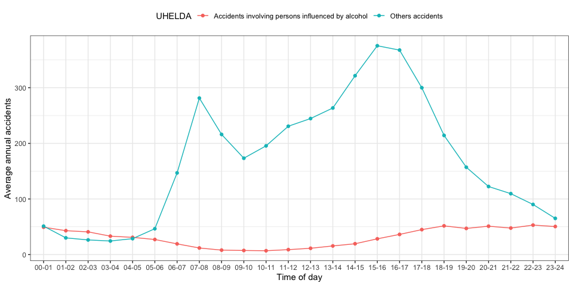

```r
accidents_by_hour %>%
    ggplot(aes(x = KLOK, y = mean_accidents, color = UHELDA, group = UHELDA)) +
    geom_line() +
    geom_point() +
    theme_bw() +
  theme(legend.position="top") +
  labs(x = "Time of day", y = "Average annual accidents")
```

## Analysis 2: Alcohol sales and alcohol-related accidents

First, we summarize the accidents dataset and check the length of the series in both datasets

```r
accidents_by_year <- accidents %>%
  group_by(UHELDA, TID) %>%
  summarize(INDHOLD = sum(INDHOLD)) %>%
  ungroup()
accidents_by_year %>%
  group_by(UHELDA) %>%
  summarise(min(TID), max(TID))
```

```
#> # A tibble: 2 × 3
#>   UHELDA                                            `min(TID)` `max(TID)`
#>   <chr>                                                  <dbl>      <dbl>
#> 1 Accidents involving persons influenced by alcohol       1997       2020
#> 2 Others accidents                                        1997       2020
```

```r
alcohol_by_year <- alcohol %>%
  filter(INDHOLD != "..") %>% # the API returns ".." as missing values
  mutate(INDHOLD = as.numeric(INDHOLD))

alcohol_by_year %>%
  group_by(TYPE) %>%
  summarise(min(TID), max(TID))
```

```
#> # A tibble: 2 × 3
#>   TYPE                                                     `min(TID)` `max(TID)`
#>   <chr>                                                         <dbl>      <dbl>
#> 1 Consumption of lager equivalents, total, excl. tax free…       2000       2010
#> 2 Sales of lager equivalents, total excl. tax free beer (…       1955       2020
```

Since alcohol consumption is only available up to 2010, we will use alcohol sales as a proxy. Also, as the alcohol consumption is indexed with year 2000 as index 100, we transoform the accidents values in the same way.

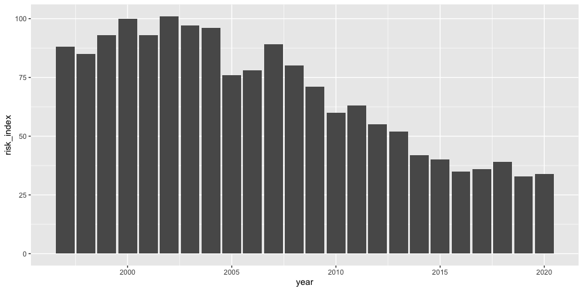

```r
alcohol_data <- alcohol_by_year %>%
  filter(between(TID, 1997, 2021),
         grepl("sales", TYPE, ignore.case = TRUE)) %>%
  select(year = TID,
         alcohol_sales = INDHOLD)

accidents_data <- accidents_by_year %>%
  filter(grepl("alcohol", UHELDA, ignore.case = TRUE)) %>%
  select(year = TID,
         alcohol_accidents = INDHOLD)

accidents_2000 <- accidents_data %>%
  filter(year == 2000) %>%
  pull(alcohol_accidents)

accidents_data$alcohol_accidents <- round((accidents_data$alcohol_accidents/accidents_2000)*100)

data <- inner_join(alcohol_data, accidents_data, by = "year") %>%
  mutate(risk_index = round(alcohol_accidents/alcohol_sales*100))

data %>%
  ggplot(aes(x=year, y=risk_index)) +
  geom_col()
```

As this vignette does not by any means aspire to the standards of rigourous academic research, we can only say here that there seems to be an **indication** that the risk of alcohol-related accidents has dropped substantially since 2000. Sales of alcohol might be a poor proxy for consumption, patterns of cross-border purchase of alcohol may have changed over the past 20 years, cars have definitely become safer over time, etc. Disentangling these effects is well beyond the scope of this article.